# Лабораторная работа №4

Операционные системы

еребрякова Д. И.

Российский университет дружбы народов, Москва, Россия

5 марта 2025

## Цель работы

Получение навыков правильной работы с репозиториями git

## Задания

1. Выполнить работу для тестового репозитория
2. Преобразовать рабочий репозиторий в репозиторий с git-flow и conventional commits

# Выполнение лабораторной работы

## Установка git-flow

Включаю copr репозиторий (рис. 1).

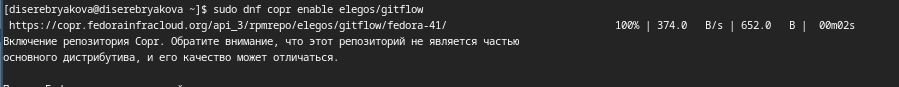

включаю copr

## Установка git-flow

Устанавливаю gitflow (рис. 2).

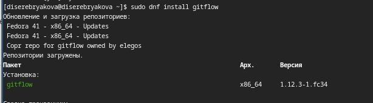

Устанавливаю gitflow

## Установка Node.js

Перехожу на роль суперпользователя (3).

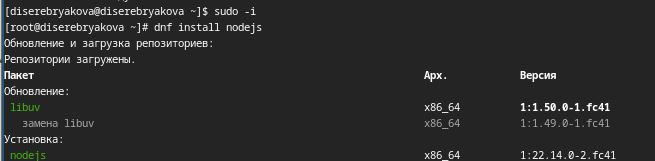

суперпользователь

## Установка Node.js

Устанавливаю nodejs и pnpm (рис. 4).

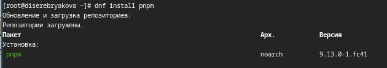

установка

## Установка Node.js

Запускаю pnpm (рис. 5).

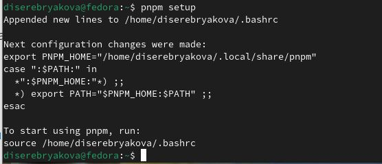

запуск

## Практический сценарий использования git

Создаю новый репозиторий (рис. 6).

[figure not shown]

новый репозиторий

## Практический сценарий использования git

Сделала к нему первый коммит и выкладываю на гитхаб (рис. 7).

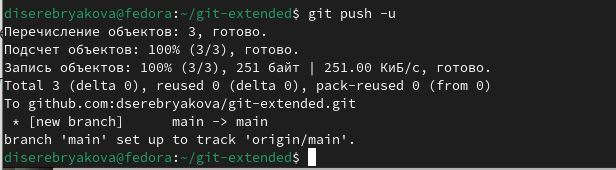

отправка на гитхаб

## Практический сценарий использования git

Редактирую файл package.json (рис. 8).

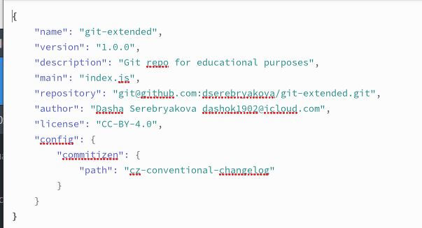

редактирую файл

## Практический сценарий использования git

Добавила новые файлы, выполнила коммит и отправила на гитхаб (рис. 9).

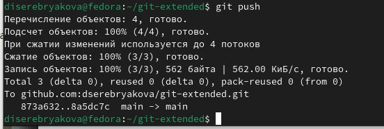

отправка на гитхаб

## Конфигурация git-flow

Инициализировала git-flow, проверяю, в какой ветке нахожусь и загружаю весь репозиторий в хранилище (рис. 10).

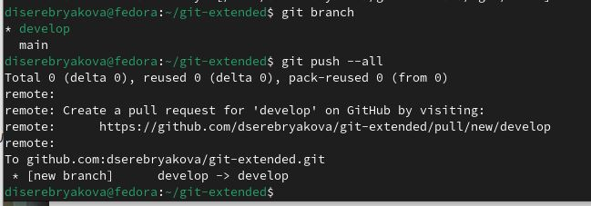

загружаю репозиторий

## Конфигурация git-flow

Создаю релиз с версией 1.0.0 (рис. 11).

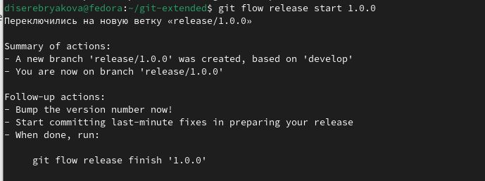

создаю релиз

## Конфигурация git-flow

Создаю журнал изменений (рис. 12).

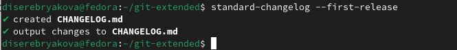

журнал измененй

## Конфигурация git-flow

Добавляю журнал изменений в индекс, заливаю релизную ветку в основную ветку и отправляю данные на гитхаб (рис. 13).

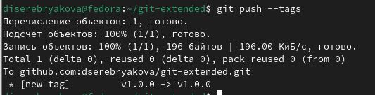

отправка на гитхаб

## Конфигурация git-flow

Выполнила вход в аккаунт гитхаб через браузер (рис. 14).

[figure not shown]

вход в гитхаб

## Работа с репозиторием git

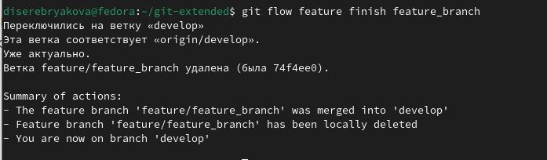

## Работа с репозиторием git

Создаю релиз с версией 1.2.3 (рис. 17).

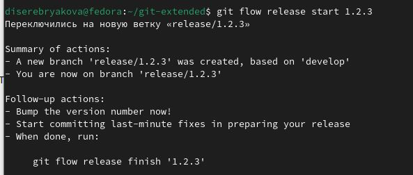

создаю релиз

## Работа с репозиторием git

Выполняю те же шаги, что и для прошлого релиза и отправляю все на гитхаб (рис. 18).

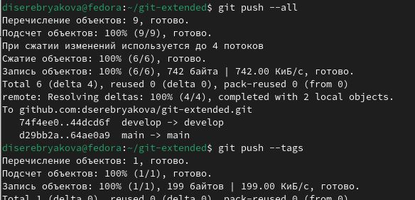

отправляю на гитхаб

## Работа с репозиторием git

Создаю релиз на github с комментарием из журнала изменений (рис. 19).

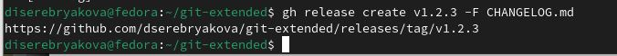

создаю релиз с комментарием

## Выводы

В ходе выполнения работы я получила навыки работы с репозиториями github

# Спасибо за внимание